# Lab8

Yunshu Ran(yran945)

2024-10-15

```r
zip = read.csv("/course/data/2024-yong/lab07/zip.csv")
```

### Digit Images

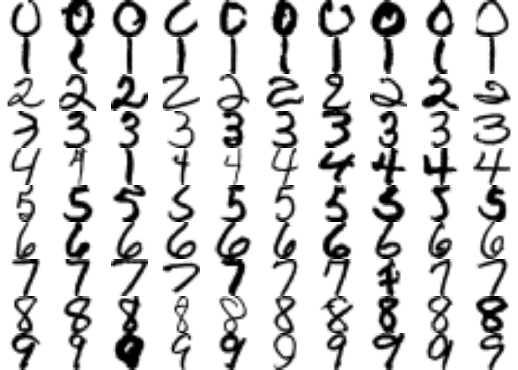

```r
# 1.
onetoten <- zip[zip$digit %in% c(0:9),]
onetoten[,-1] = (1-onetoten[,-1])/2

par(mar=rep(0,4), mfrow=c(10,10))
for(i in 0:9) {
  samples <- sample(which(onetoten$digit == i), 10)
  for(j in samples) {
    matrix_image <- matrix(as.numeric(onetoten[j,2:257]), nrow=16, ncol=16, byrow=TRUE)
    plot(as.raster(matrix_image))
  }
}
```

```r
# 2.
data <- zip[zip$digit %in% c(6,8), c("digit", "p75", "p91")]
data$digit <- factor(data$digit)
data$digit <- ifelse(data$digit==6, 0, 1)
train = data[1:500,]
test = data[-(1:500),]
model = keras_model_sequential() |>
  layer_dense(units=3, activation="sigmoid", input_shape=2) |>  # 2 predictors, 3 units in hidden layer
  layer_dense(units=1, activation="sigmoid")                    # 2 classes

model |> compile(loss="binary_crossentropy",
                 optimizer=optimizer_rmsprop(),
                 metrics=c("accuracy"))
xmat = as.matrix(train[,2:3])
ymat = as.matrix(train[,1])
system.time(history <- model |> fit(xmat, ymat, verbose=0, epochs=500, batch_size=32))
```

```
##    user  system elapsed
##  22.763   2.446  17.800
```

[output not shown]

```r
yhat = model |> predict(xmat, verbose=0)
yhat = ifelse(yhat > 0.5, 1, 0)
mean(yhat != ymat)                   # training error
```

```
## [1] 0.1
```

```r
yhat = model |> predict(as.matrix(test[,2:3]), verbose=0)
yhat = ifelse(yhat > 0.5, 1, 0)
mean(yhat != as.matrix(test[,1]))                   # test error
```

```
## [1] 0.08445298
```

```r
# 3.
model2 = keras_model_sequential() |>
  layer_dense(units=2, activation="sigmoid", input_shape=2) |>  # 2 predictors, 2 units in hidden layer
  layer_dense(units=3, activation="sigmoid") |>                 # 3 units in hidden layer
  layer_dense(units=1, activation="sigmoid")                    # 2 classes

model2 |> compile(loss="binary_crossentropy",
                 optimizer=optimizer_rmsprop(),
                 metrics=c("accuracy"))
xmat = as.matrix(train[,2:3])
ymat = as.matrix(train[,1])
system.time(history <- model2 |> fit(xmat, ymat, verbose=0, epochs=500, batch_size=32))
```

```
##    user  system elapsed
##  23.916   2.534  17.816
```

[output not shown]

```r
yhat = model2 |> predict(xmat, verbose=0)
yhat = ifelse(yhat > 0.5, 1, 0)
mean(yhat != ymat)                   # training error
```

```
## [1] 0.09
```

```r
yhat = model2 |> predict(as.matrix(test[,2:3]), verbose=0)
yhat = ifelse(yhat > 0.5, 1, 0)
mean(yhat != as.matrix(test[,1]))                   # test error
```

```
## [1] 0.0815739
```

```r
# grid setting
x_min <- min(train$p75) - 0.5
x_max <- max(train$p75) + 0.5
y_min <- min(train$p91) - 0.5
y_max <- max(train$p91) + 0.5
x_seq <- seq(x_min, x_max, length.out = 101)
y_seq <- seq(y_min, y_max, length.out = 101)
grid <- expand.grid(p75 = x_seq, p91 = y_seq)
grid_xmat <- as.matrix(grid)

yhat_model1 <- model |> predict(grid_xmat)
```

```
## 319/319 - 0s - 336ms/epoch - 1ms/step
```

```r
z1 <- matrix(yhat_model1, nrow = 101, byrow = TRUE)
yhat_model2 <- model2 |> predict(grid_xmat)
```

```
## 319/319 - 0s - 339ms/epoch - 1ms/step
```

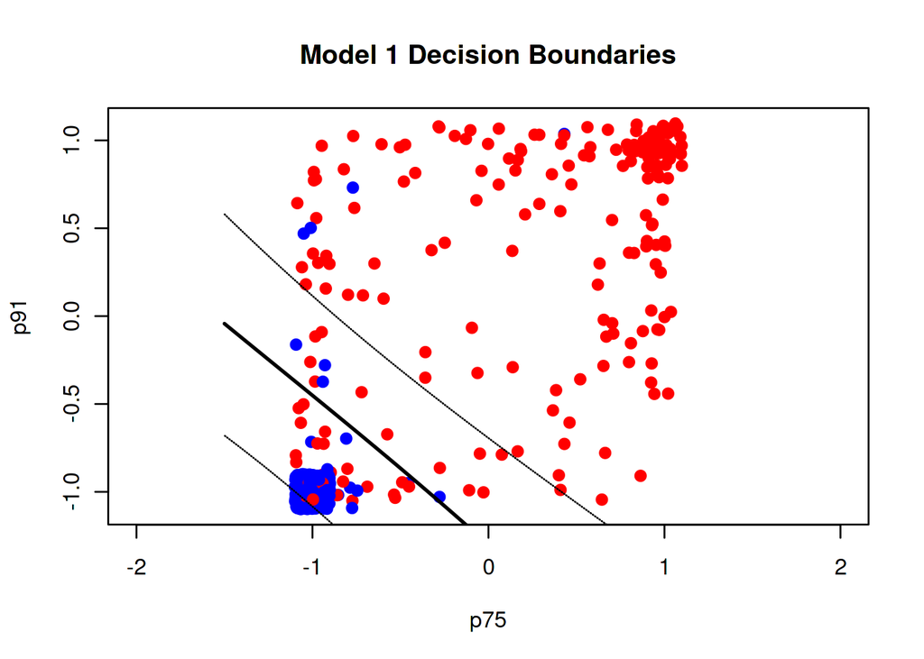

```r
z2 <- matrix(yhat_model2, nrow = 101, byrow = TRUE)

col <- ifelse(train$digit == 1, "red", "blue")

# add jitter
train_jitter <- train
train_jitter$p75 <- jitter(train_jitter$p75, amount = 0.1)
train_jitter$p91 <- jitter(train_jitter$p91, amount = 0.1)

# Model1
plot(train_jitter$p75, train_jitter$p91, col = col, pch = 19,
     xlab = "p75", ylab = "p91", main = "Model 1 Decision Boundaries", asp = 1)
contour(x_seq, y_seq, z1, levels = c(0.1, 0.5, 0.9), lwd = c(1, 2, 1),
        lty = c(3, 1, 3), drawlabels = FALSE, add = TRUE)
```

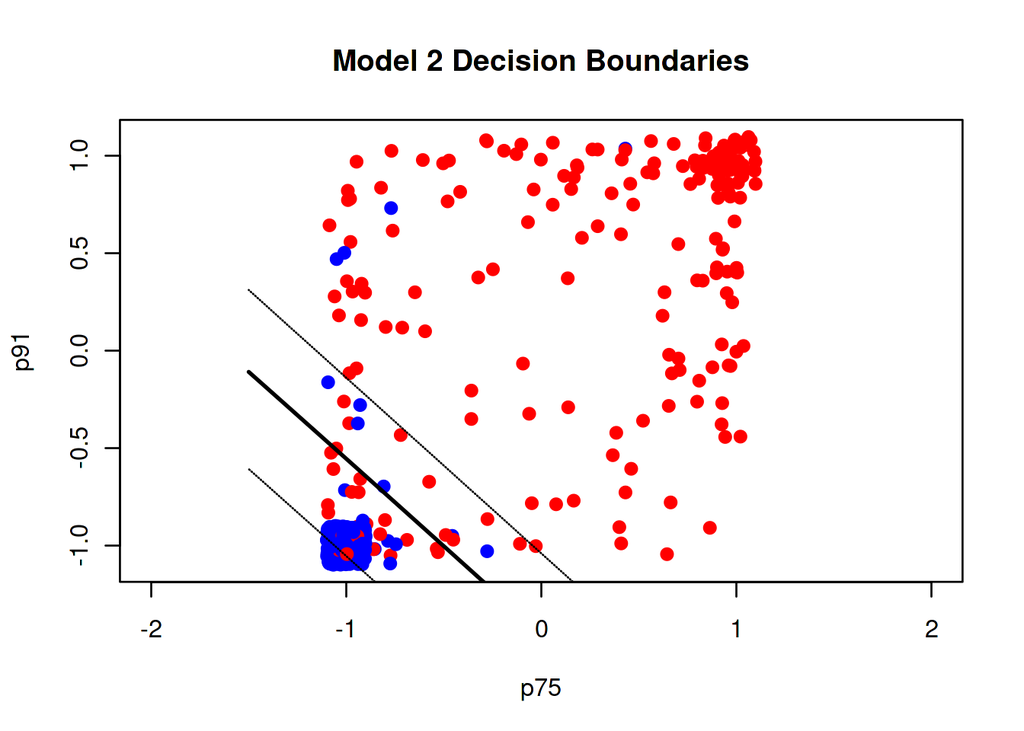

```r
# Model2
plot(train_jitter$p75, train_jitter$p91, col = col, pch = 19,
     xlab = "p75", ylab = "p91", main = "Model 2 Decision Boundaries", asp = 1)
contour(x_seq, y_seq, z2, levels = c(0.1, 0.5, 0.9), lwd = c(1, 2, 1),
        lty = c(3, 1, 3), drawlabels = FALSE, add = TRUE)
```

###### 5. Explain in detail how the number of parameters at each layer is computed in the neural network used in Question 3.

1. First Hidden Layer (2 unis): weights = 2 input features * 2 units = 4 weights Biases = 2 Total = 4+2 = 6 parameters
2. Second Hidden Layer (3 unis): weights = 2 input features * 3 units = 6 weights Biases = 3 Total = 6+3 = 9 parameters
3. Output Layer (1 unis): weights = 3 input features * 1 unit = 3 weights Biases = 1 Total = 3+1 = 4 parameters